[figure not shown]

# Simple Linear Regression with Sacramento Real Estate Data

*Authors: Matt Brems, Sam Stack*

In this lab you will hone your EDA skills and practice constructing simple linear regressions using a dataset on Sacramento real estate sales. The dataset contains information on qualities of the property, location of the property, and time of sale.

### 1. Read in the Sacramento housing data set.

```python
# sac_csv = '../../data/sacramento_real_estate_transactions.csv'
sac_csv = 'data/sacramento_real_estate_transactions.csv'
```

```python
import pandas as pd
import seaborn as sns
import matplotlib.pyplot as plt
import numpy as np
import scipy.stats

%matplotlib inline
```

```python
data = pd.read_csv(sac_csv, parse_dates=True)
```

```python
data.sample(n=5)
data.sale_date.unique()
```

```
array(['Wed May 21 00:00:00 EDT 2008', 'Tue May 20 00:00:00 EDT 2008',
       'Mon May 19 00:00:00 EDT 2008', 'Fri May 16 00:00:00 EDT 2008',
       'Thu May 15 00:00:00 EDT 2008'], dtype=object)
```

```python
data['sale_date'] = data.sale_date.apply(lambda x: x.replace('2008', ""))
data['sale_date'] = data.sale_date.apply(lambda x: x.replace('00:00:00', ""))
data['sale_date'] = data.sale_date.apply(lambda x: x.replace('EDT', ""))

data['sale_date'] = data.sale_date.apply(lambda x: x.replace('May 19', ""))
data['sale_date'] = data.sale_date.apply(lambda x: x.replace('May 20', ""))
data['sale_date'] = data.sale_date.apply(lambda x: x.replace('May 21', ""))
data['sale_date'] = data.sale_date.apply(lambda x: x.replace('May 15', ""))
data['sale_date'] = data.sale_date.apply(lambda x: x.replace('May 16', ""))
```

```python
data.head()
```

|  | street | city | zip | state | beds | baths | sq__ft | type | sale_date | price | latitude | longitude |
| --- | --- | --- | --- | --- | --- | --- | --- | --- | --- | --- | --- | --- |
| 0 | 3526 HIGH ST | SACRAMENTO | 95838 | CA | 2 | 1 | 836 | Residential | Wed | 59222 | 38.631913 | -121.434879 |
| 1 | 51 OMAHA CT | SACRAMENTO | 95823 | CA | 3 | 1 | 1167 | Residential | Wed | 68212 | 38.478902 | -121.431028 |
| 2 | 2796 BRANCH ST | SACRAMENTO | 95815 | CA | 2 | 1 | 796 | Residential | Wed | 68880 | 38.618305 | -121.443839 |
| 3 | 2805 JANETTE WAY | SACRAMENTO | 95815 | CA | 2 | 1 | 852 | Residential | Wed | 69307 | 38.616835 | -121.439146 |
| 4 | 6001 MCMAHON DR | SACRAMENTO | 95824 | CA | 2 | 1 | 797 | Residential | Wed | 81900 | 38.519470 | -121.435768 |

```python
data.isnull().sum()
```

```
street       0
city         0
zip          0
state        0
beds         0
baths        0
sq__ft       0
type         0
sale_date    0
price        0
latitude     0
longitude    0
dtype: int64
```

```python
data.shape
```

```
(985, 12)
```

### 2. Conduct exploratory data analysis on this data set.

**Report any notable findings here and any steps you take to clean/process data.**

> **Note:** These EDA checks should be done on every data set we give you. If you find yourself checking for, say, missing/corrupted data over and over, it might be to your long-term benefit to have a function that you can re-use every time you're given some new data.

```python
# A:
data.describe()
```

|  | zip | beds | baths | sq__ft | price | latitude | longitude |
| --- | --- | --- | --- | --- | --- | --- | --- |
| count | 985.000000 | 985.000000 | 985.000000 | 985.000000 | 985.000000 | 985.000000 | 985.000000 |
| mean | 95750.697462 | 2.911675 | 1.776650 | 1312.918782 | 233715.951269 | 38.445121 | -121.193371 |
| std | 85.176072 | 1.307932 | 0.895371 | 856.123224 | 139088.818896 | 5.103637 | 5.100670 |
| min | 95603.000000 | 0.000000 | 0.000000 | -984.000000 | -210944.000000 | -121.503471 | -121.551704 |
| 25% | 95660.000000 | 2.000000 | 1.000000 | 950.000000 | 145000.000000 | 38.482704 | -121.446119 |
| 50% | 95762.000000 | 3.000000 | 2.000000 | 1304.000000 | 213750.000000 | 38.625932 | -121.375799 |
| 75% | 95828.000000 | 4.000000 | 2.000000 | 1718.000000 | 300000.000000 | 38.695589 | -121.294893 |
| max | 95864.000000 | 8.000000 | 5.000000 | 5822.000000 | 884790.000000 | 39.020808 | 38.668433 |

### 3. Our goal will be to predict price. List variables that you think qualify as predictors of price in a SLR model.

**For each of these variables you believe to be valid potential predictors in an SLR model, generate a plot showing the relationship between the independent variable and dependent variable.**

```python
data.head()
```

|  | street | city | zip | state | beds | baths | sq__ft | type | sale_date | price | latitude | longitude |
| --- | --- | --- | --- | --- | --- | --- | --- | --- | --- | --- | --- | --- |
| 0 | 3526 HIGH ST | SACRAMENTO | 95838 | CA | 2 | 1 | 836 | Residential | Wed | 59222 | 38.631913 | -121.434879 |
| 1 | 51 OMAHA CT | SACRAMENTO | 95823 | CA | 3 | 1 | 1167 | Residential | Wed | 68212 | 38.478902 | -121.431028 |
| 2 | 2796 BRANCH ST | SACRAMENTO | 95815 | CA | 2 | 1 | 796 | Residential | Wed | 68880 | 38.618305 | -121.443839 |
| 3 | 2805 JANETTE WAY | SACRAMENTO | 95815 | CA | 2 | 1 | 852 | Residential | Wed | 69307 | 38.616835 | -121.439146 |
| 4 | 6001 MCMAHON DR | SACRAMENTO | 95824 | CA | 2 | 1 | 797 | Residential | Wed | 81900 | 38.519470 | -121.435768 |

```python
data.type.unique()
```

```
array(['Residential', 'Condo', 'Multi-Family', 'Unkown'], dtype=object)
```

```python
# convert the type of home to dummy variables
type_dummies = pd.get_dummies(data.type, prefix='type')
# drop one column of the dummy types
type_dummies.drop(type_dummies.columns[0], axis=1, inplace=True)
# concatenate the new dummy variables to the dummy df
data_dummies = pd.concat([data, type_dummies], axis=1)
```

```python
data_dummies.drop(['type'], axis=1, inplace=True)
data_dummies.drop(['zip'], axis=1, inplace=True)
data_dummies.drop(['city'], axis=1, inplace=True)
data_dummies.drop(['state'], axis=1, inplace=True)
data_dummies.drop(['latitude'], axis=1, inplace=True)
data_dummies.drop(['longitude'], axis=1, inplace=True)
data_dummies.drop(['sale_date'], axis=1, inplace=True)
data_dummies.drop(['street'], axis=1, inplace=True)

# data_dummies.rename(columns={'sale_date_Mon    ':'sale_date_Mon',
#                           'sale_date_Tue    ':'sale_date_Tue',
#                           'sale_date_Wed    ':'sale_date_Wed',
#                           'sale_date_Thu    ':'sale_date_Thu'},
#                  inplace=True)
```

```python
X = data_dummies[['beds', 'baths',
                  'sq__ft', 'type_Multi-Family',
                  'type_Residential', 'type_Unkown',
                 ]]

y = data_dummies['price']
```

### 4. Which variable would be the best predictor of Y in a SLR model? Why?

# A:

sq_ft would likey have a significant predictive value on price given that it is a significant function of price

### 5. Build a function that will take in two lists `Y` and `X` and returns the intercept and slope coefficients that minimize SSE.

`Y` is the target variable and `X` is the predictor variable.

- **Test your function on price and the variable you determined was the best predictor in Problem 4.**
- **Report the slope and intercept.**

```python
# A
from sklearn.model_selection import train_test_split
from sklearn.linear_model import LinearRegression
from sklearn import metrics

lr = LinearRegression()
X_train, X_test, y_train, y_test = train_test_split(X, y, test_size = 0.2, random_state = 6)
```

```python
# A:
lr.fit(X_train, y_train)
```

```
LinearRegression(copy_X=True, fit_intercept=True, n_jobs=None, normalize=False)
```

```python
print(lr.intercept_)
print(lr.coef_)
```

```
59533.16245147519
[-1.60224275e+04  7.21380612e+04  2.49922672e+01 -2.97459543e+04
  6.59701715e+04  2.15466838e+05]
```

### 6. Interpret the intercept. Interpret the slope.

# A:

# the intercept value B0 = 59533.16 can be interpreted as the value of Y if all explanatory variables Xi = 0

## the base price of a home in sacramento is roughly $59,533 assuming all other variables X are equal to zero

### 7. Give an example of how this model could be used for prediction and how this model could be used for inference.

**Be sure to make it clear which example is associated with prediction and which is associated with inference.**

# A:

## the beta values can be used to draw inferences between the independant variables X and the dependant varaible Y. Such that a given change in beta coefficients will indicate how changes in Xi will be reflected in y

### 8: [Bonus] Using the model you came up with in Problem 5, calculate and plot the residuals.

```python
# A:

y_hat = lr.predict(X_test)
test_rmse = np.sqrt(metrics.mean_squared_error(y_test, y_hat))


print(round(test_rmse, 2))
```

```
132078.74
```

```python
print(y_hat.shape)
print(y_test.shape)
```

```
(197,)
(197,)
```

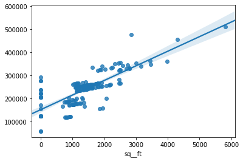

```python
# plt.scatter(X_test['beds'], y_hat)
sns.regplot(X_test['sq__ft'], y_hat)
```

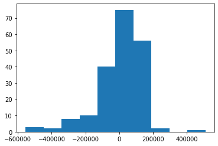

```python
plt.hist(y_hat-y_test)
```

```python
sns.lmplot(x='beds', y='price', data=data, size=(10));
plt.xlim(-2, 10);
plt.ylim(-2, 1000000);
```

[output not shown]

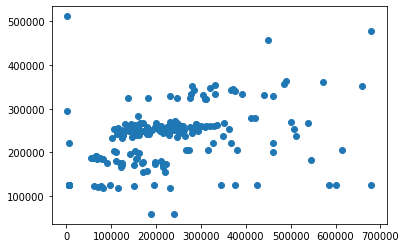

```python
plt.scatter(y_test,y_hat)
```